# Analysis for ‘Colour biases in learned foraging preferences in Trinidadian guppies’

Guppy colour learning project site [GitHub](https://github.com/wyatt-toure/guppy-colour-learning-project) Analysis Methods Home

M. Wyatt Toure, Simon M. Reader

McGill University, Department of Biology, 1205 Docteur Penfield, Montreal, Quebec H3A 1B1, Canada

Corresponding Author:  
M. Wyatt Toure  
e-mail: `m_wyatt.toure@mail.mcgill.ca`

Date of last update: Apr 21 2021

## Brief Overview

This page reports the analyses for the experiment described in ‘Colour biases in learned foraging preferences in Trinidadian guppies’. The raw data used to conduct these analyses are available in the colour-learning-project-data.csv file. Descriptions of the variables found in the dataset are given in the metadata section of the [README](https://github.com/wyatt-toure/guppy-colour-learning-project#metadata) file. The R script to reproduce the analysis and this site are in the analysis-script-colour-project.Rmd file. The methods used to produce this data can be found on the Methods page.

## Models

We analysed the data from our experiment using linear mixed effect and generalized linear mixed effect models with the `lmer()` and `glmer()` functions from the `lme4` package. P-values and effective degrees of freedom were obtained using the `lmerTest` package. Model residuals were checked they met distributional assumptions with the `DHARMa` package, you can click the ‘See Model Residuals’ button below the model formulas to see the residual diagnostic plots produced by `DHARMa` for that particular model.

### Model 1 - Preference for the green object at baseline

This first model contains the data for all individual guppies. I looked at the green object preference of all guppies in an intercept only model to see if the green object preference at baseline was significantly different from zero. `green.object.preference` is the time spent near the green object subtracted by the time spent near the blue object

```r
baseline_data_model <-
  lm(green.object.preference ~ 1,
    data = baseline_data
  )
```

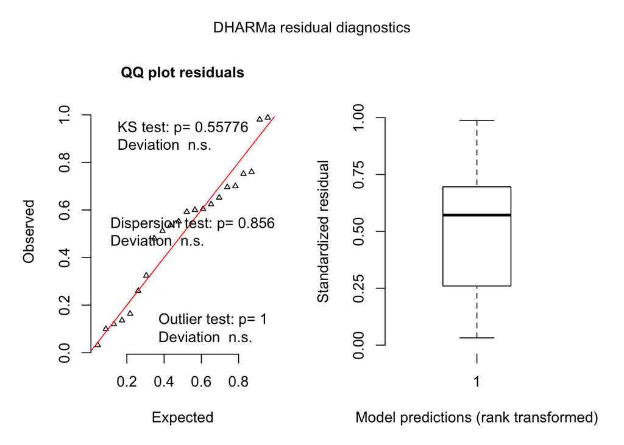

##### Result

| Factor | Estimate | Std. Error | T statistic | P value |
| --- | --- | --- | --- | --- |
| Intercept | 1.065 | 3.008 | 0.354 | 0.727 |

During the initial test, there was no significant preference for the green object across all guppies (p = 0.727).

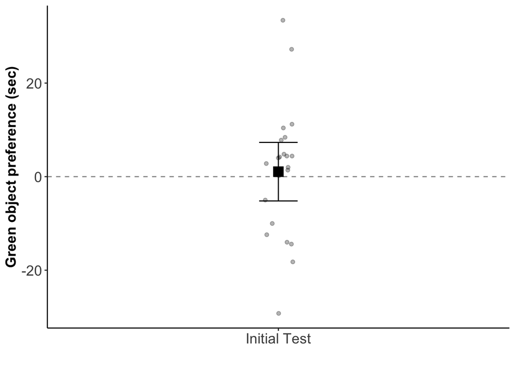

Figure 1: Preference for the green object relative to the blue object across all guppies at baseline. Negative values represent more time spent with the blue object, positive values indicate more time spent with the green object. Data are means +/- 95% CI

### Model 2 - Preference for the rewarding object during training

To see whether fish were responsive during training our second model asks whether the preference for the rewarding object changes throughout training and whether the change in rewarding object preference is different between the treatments.

- **Response variable:** `rewarding.object.preference` is the time (seconds) spent near the rewarding object subtracted by the time spent near the unrewarding object
- **Fixed effect:** `rewarding.object.colour` is the identity of the rewarding object (blue or green)
- **Fixed effect:** `trial` is the number of the training trial. In this model it is supplied as an integer
- **Random effect:** `id` is the identity of the individual fish

```r
training_data_model <-
  lmer(rewarding.object.preference ~ rewarding.object.colour * trial + (1 | id),
    data = training_data
  )
```

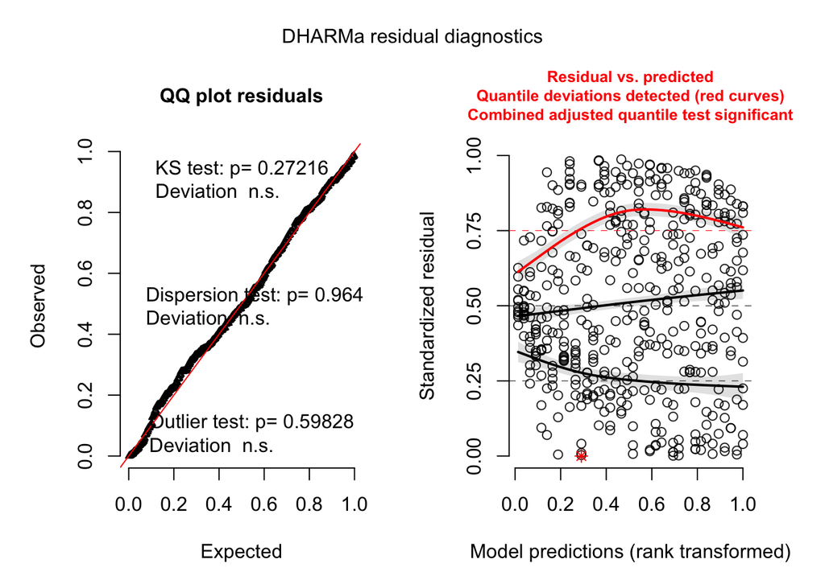

There is a slight deviation in the upper quantile but no indication in the residual plot of a gross model misfit.

##### Results

| Factor | Estimate | Std. Error | T statistic | df | P value |
| --- | --- | --- | --- | --- | --- |
| Intercept | -11.017 | 19.490 | -0.565 | 48.463 | 0.575 |
| Reward object colour | 55.989 | 27.341 | 2.048 | 47.159 | 0.046 |
| Trial | 7.700 | 1.085 | 7.098 | 438.052 | < .001 |
| Rewarding object colour X Trial | -0.549 | 1.490 | -0.368 | 434.792 | 0.713 |

There was a significant effect of trial. Over the 20 training trials, guppies in the two treatments increased their relative preference for their respective rewarded objects by 7.7 seconds each trial (Figure 2, p < .001). There was also a significant effect of rewarded-object colour (p = 0.046). during training green-rewarded guppies expressed a stronger preference for their rewarded object (the green object) than did blue-rewarded guppies did for the blue object. However, there was no significant interaction effect between rewarding object colour and trial (p = 0.713), *i.e.*, the rate of increase in object preference over trials did not significantly differ between the treatments.

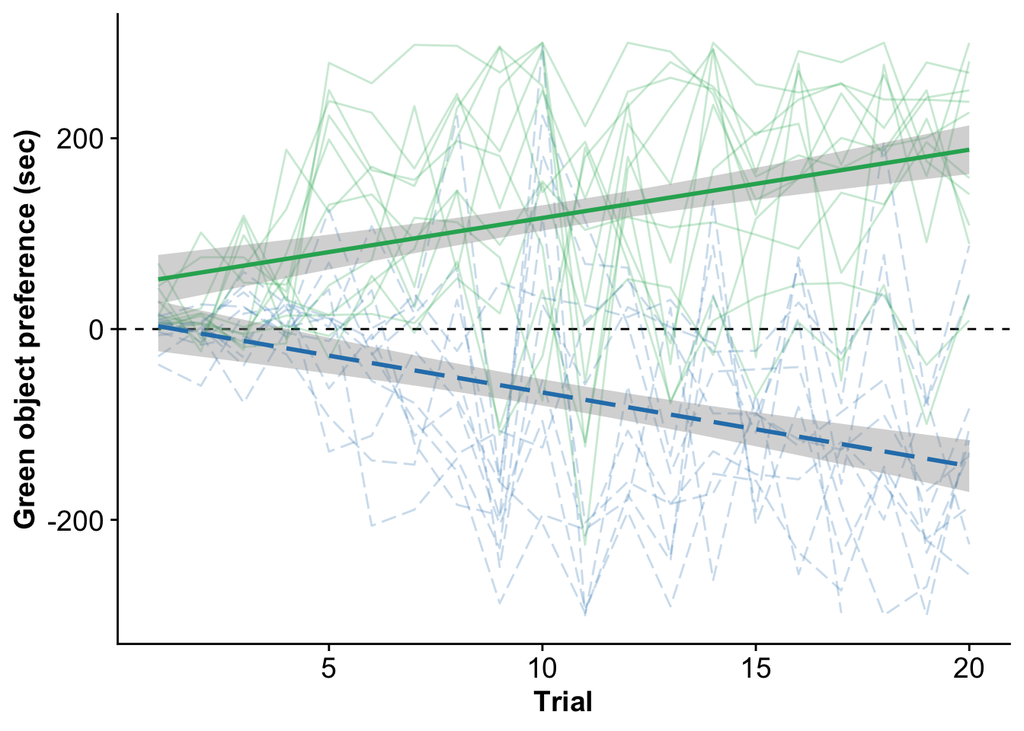

Figure 2: Relative preference for the green object in both treatments during training trials (trials 1-20). Negative values represent more time spent with the blue object, positive values indicate more time spent with the green object. Light lines connect individuals across trials and bold lines represents a linear fit with 95% CI (grey shading). Subjects were consistently rewarded for approaching the blue object (dashed lines) or the green object (solid lines).

### Model 3 - Preference for the rewarded object during testing depending on treatment

For the main effects of training and rewarding object colour on rewarding object preference I fit a generalized linear mixed effects model with a Gaussian distribution which modeled the variances to account for variance heterogeneity using the package [`glmmTMB`](https://cran.r-project.org/web/packages/glmmTMB/index.html). My third model asks whether the preference for the rewarding object changed between baseline and final test and looks for an interaction with rewarded object colour.

- **Response variable:** `rewarding.object.preference` is the time (seconds) spent near the rewarding object subtracted by the time spent near the unrewarding object
- **Fixed effect:** `rewarding.object.colour` is the identity of the rewarding object (blue or green)
- **Fixed effect:** `trial` is the number of the training trial. In this model it is supplied as a factor where 0 is the baseline trial and 21 is the final trial
- **Random effect:** `id` is the identity of the individual fish

```r
test_data_model_glm =
  glmmTMB(rewarding.object.preference ~
            trial * rewarding.object.colour + (1|id) +
            diag(0 + rewarding.object.colour:trial |id),
  data = test_data,
  family = gaussian
  )
```

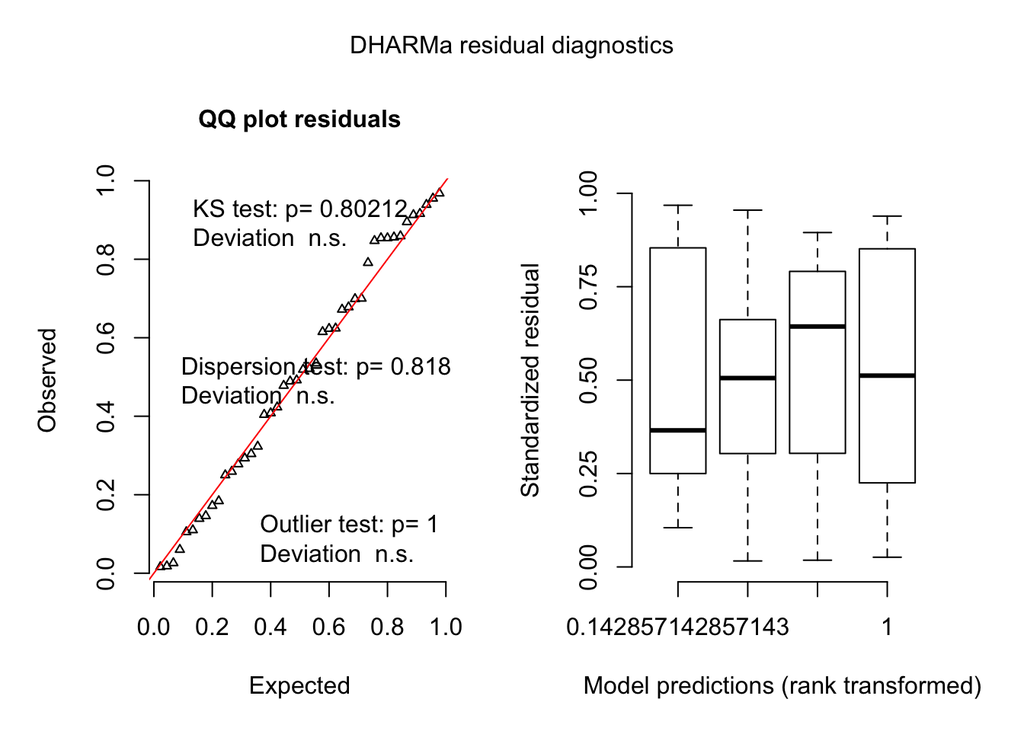

##### Results

Table 1: Summary table for Model 3. Estimates ± standard error (SE) of the effects of trial and rewarding object colour on the rewarding object preference from the generalized linear mixed effect model containing the effects Trial, Rewarding object colour, and their interaction effect (Trial X Rewarding object colour).

| Factor | Estimate | Std. Error | T statistic | P value |
| --- | --- | --- | --- | --- |
| Intercept | 1.842 | 3.011 | 0.612 | 0.541 |
| Trial | 17.697 | 10.017 | 1.767 | 0.077 |
| Rewarding object colour | 1.645 | 5.542 | 0.297 | 0.767 |
| Rewarding object colour X Trial | 65.351 | 20.832 | 3.137 | 0.002 |

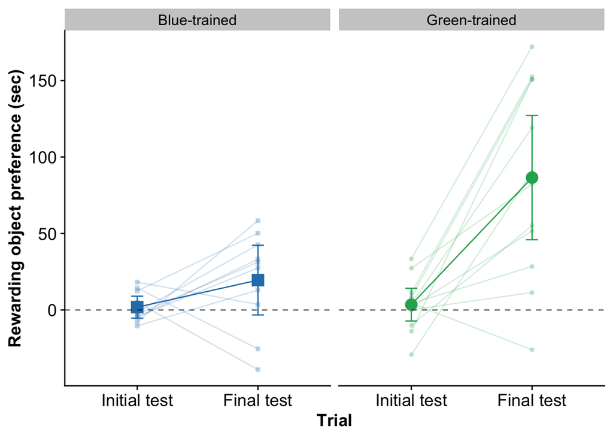

#### Post-hoc Comparisons

To determine whether the means of the final rewarding object preference for the two treatments were different I conducted post-hoc comparisons with the package [`emmeans`](https://cran.r-project.org/package=emmeans). I compared the following means:

- Final test blue-trained and initial test blue-trained
- Final test green-trained and initial test green-trained
- Final test green-trained and final test blue-trained
- Initial test green-trained and initial test blue-trained

```r
test_data_model_emmeans <- emmeans(test_data_model_glm,
  specs = ~ trial:rewarding.object.colour
)

# Making vectors to represent means of interest from emmeans() output
blue0 <- c(1, 0, 0, 0)
blue21 <- c(0, 1, 0, 0)
green0 <- c(0, 0, 1, 0)
green21 <- c(0, 0, 0, 1)

# Set seed to prevent confidence intervals from changing when code is re-run
set.seed(123)

custom_contrasts <- contrast(test_data_model_emmeans,
  method = list(
    "21 blue - 0 blue" = blue21 - blue0,
    "21 green - 0 green " = green21 - green0,
    "21 green - 21 blue" = green21 - blue21,
    "0 green - 0 blue" = green0 - blue0
  ), adjust = "mvt"
) %>%
  summary(infer = TRUE)
```

##### Results

Table 2: Table of post-hoc tests with a multivariate-t adjustment for multiple comparisons of a selected set of means. The numbers represent the initial test (0) and the final test (21). The colour corresponds to the identity of the rewarding object (blue for blue-rewarded guppies, green for green-rewarded guppies). Values are all rounded to 3 decimal places. CL = confidence limit.

| Contrast | Estimate | Lower CL | Upper CL | df | P Value |
| --- | --- | --- | --- | --- | --- |
| 21 blue - 0 blue | 17.697 | -7.968 | 43.363 | 34 | 0.251 |
| 21 green - 0 green | 83.048 | 36.247 | 129.849 | 34 | < .001 |
| 21 green - 21 blue | 66.996 | 15.542 | 118.449 | 34 | 0.007 |
| 0 green - 0 blue | 1.645 | -12.555 | 15.845 | 34 | 0.988 |

Post-hoc comparisons (Table 2) reveal that initially, before training, there was no significant difference in the strength of preference for the rewarded object between the treatments (p = 0.988). The shift in rewarded object preference between the initial and final preference tests was significant for green-trained guppies but not for blue-trained guppies: green trained guppies increased their preference for the green object by 83 seconds from initial to final (p < .001) test whereas blue-trained guppies increased their preference for the blue object by 17.7 seconds an effect that was not statistically significant (p = 0.251). At final test, green-rewarded guppies had a significantly stronger preference for the previously rewarded object compared to the blue-rewarded guppies (p = 0.007).

### Model 4 - Is there a difference in feeding attempts between treatments?

A discrepancy in reinforcement between treatments may influence performance on a final preference test. To see whether there was a difference in feeding between treatments I counted the number of trials in which an individual fish ate throughout all of training and compared the feeding counts between treatments. To do this I fit a generalized linear model with a negative binomial distribution. The response variable ‘feeding count’ is a sum of the number of trials in which a guppy ate.

- **Response variable:** `feeding.count` is the number of trials in which an individual fish ate
- **Fixed effect:** `rewarding.object.colour` is the identity of the rewarding object (blue or green)

##### Model

```r
feeding_data_model <-
  glm.nb(feeding.count ~ rewarding.object.colour,
    data = my_feeding_data
  )
```

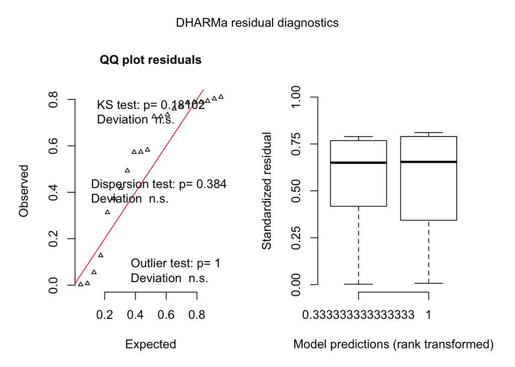

##### Results

| Factor | Estimate | Std. Error | T statistic | P value |
| --- | --- | --- | --- | --- |
| Intercept | 2.407 | 0.195 | 12.351 | 0.000 |
| Rewarding object colour | 0.071 | 0.263 | 0.270 | 0.787 |

We found no significant difference in the number of trials individuals fed between green-rewarded and blue-rewarded fish (Figure 4, p = 0.787). Removing the one individual that did not feed during training gave a similar result (p = 0.87). We also incorporated feeding count as a covariate in Model 3, finding the same pattern of results (See ESM Model 2).

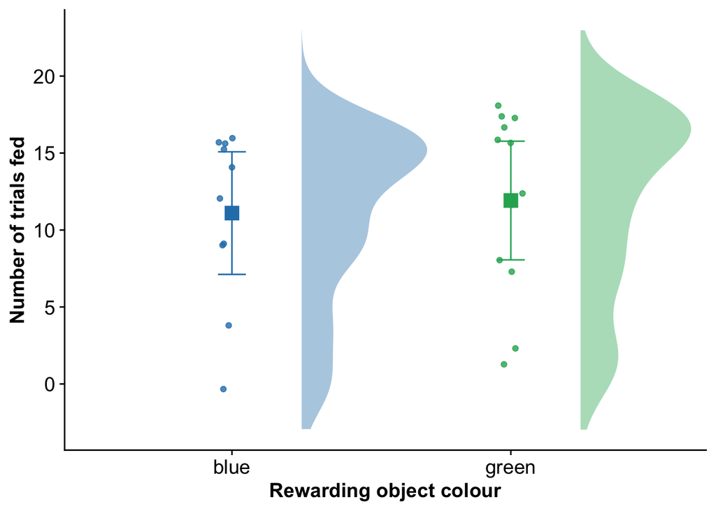

Figure 4: Average number of trials in which a fish fed during training. Data are means ± 95% confidence intervals with probability density functions of the data (showing the negative binomial distribution) to the right of the raw data.

## ESM Models

In this section we describe models not included in the main text.

### Addressing feeding count

The models described in this section were run to address the potential role of feeding count on test performance. The concern was that the results may be explained by differential levels of reinforcement between the groups or between individuals during training. To ensure our results were robust to matters arising from feeding count variation we:

1. Removed an individual that did not feed and re-ran the analysis in Model 3
2. Included feeding count as a co-variate and re-ran the analysis in Model 3

#### ESM Model 1 - Removing individual that did not feed

There is a fish that did not eat during any trials, however removing this individual does not change the conclusions

```r
test_feeding_data_low_feeders_removed <-
  test_feeding_data %>% filter(feeding.count > 0)
```

##### Model

```r
test_feeding_data_low_feeders_removed_model <-
  glmmTMB(rewarding.object.preference ~
  trial * rewarding.object.colour + (1 | id) +
    diag(0 + rewarding.object.colour:trial | id),
  data = test_feeding_data_low_feeders_removed,
  family = gaussian
  )
```

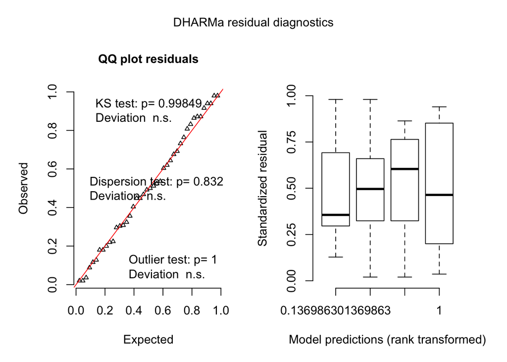

##### Results

| Factor | Estimate | Std. Error | T statistic | P value |
| --- | --- | --- | --- | --- |
| Intercept | 0.445 | 3.004 | 0.148 | 0.882 |
| Trial | 24.090 | 9.694 | 2.485 | 0.013 |
| Rewarding object colour | 3.042 | 5.538 | 0.549 | 0.583 |
| Rewarding object colour X Trial | 58.958 | 20.679 | 2.851 | 0.004 |

#### ESM Model 2 - Including feeding count as a covariate

With this next model we looked to see whether including the amount of trials an individual fed as a covariate in the model changes the conclusions.

- **Response variable:** `rewarding.object.preference` is the time (seconds) spent near the rewarding object subtracted by the time spent near the unrewarding object
- **Fixed effect:** `rewarding.object.colour` is the identity of the rewarding object (blue or green)
- **Fixed effect:** `trial` is the number of the training trial. In this model it is supplied as an integer
- **Random effect:** `id` is the identity of the individual fish
- **Covariate:** `feeding.count` is the number of trials in which an individual fish ate

```r
test_data_feeding_controlled_model <-
  glmmTMB(rewarding.object.preference ~
  trial * rewarding.object.colour + feeding.count + (1 | id) +
    diag(0 + rewarding.object.colour * trial | id),
  data = test_feeding_data,
  family = gaussian
  )
```

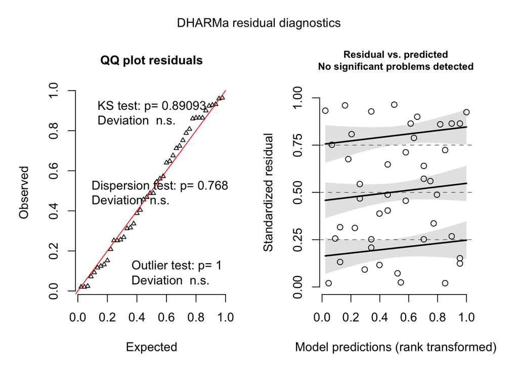

##### Results

Table 3: Summary table for a modification of Model 3. This model is the same as that described in Table S1 except it includes feeding count as a covariate. Estimates ± standard error (SE) of the effects of trial and rewarding object colour of the rewarding object colour from the generalized linear mixed effect model containing the effects (Trial, Rewarding object colour, and their interaction effect).

| Factor | Estimate | Std. Error | T statistic | P value |
| --- | --- | --- | --- | --- |
| Intercept | -3.642 | 7.215 | -0.505 | 0.614 |
| Trial | 17.697 | 9.553 | 1.852 | 0.064 |
| Rewarding object colour | 1.241 | 5.514 | 0.225 | 0.822 |
| Feeding count | 0.494 | 0.579 | 0.854 | 0.393 |
| Rewarding object colour X Trial | 65.352 | 19.847 | 3.293 | < .001 |

The main results do not change if I control for feeding count. The above table is the output feeding controlled model. Below we have the output table for the non-feeding-count controlled model from Model 3.

| Factor | Estimate | Std. Error | T statistic | P value |
| --- | --- | --- | --- | --- |
| Intercept | 1.842 | 3.011 | 0.612 | 0.541 |
| Trial | 17.697 | 10.017 | 1.767 | 0.077 |
| Rewarding object colour | 1.645 | 5.542 | 0.297 | 0.767 |
| Rewarding object colour X Trial | 65.351 | 20.832 | 3.137 | 0.002 |

In both models the p-values are similar. While the effect of feeding count is not significant (p = 0.393) the effect of feeding count trends in the expected direction in our feeding count controlled model. As feeding count increases the preference for the rewarding object colour also increases.

### Feeding and object preferences

This is a model I (Wyatt) ran just because I was curious.

#### ESM Model 3 - Preference for the rewarded object during training based on feeding

This model asks whether the time spent near the rewarding object during a training session is influenced by whether a fish ate or not. Here trial is a variable containing the training trials (1-20). It is supplied as a random effect along with individual ID in the model.

##### Model

```r
training_data_model_rewarding_object <-
  lmer(rewarding.object.preference ~ ate + (1 | id) + (1 | trial),
    data = training_data
  )
```

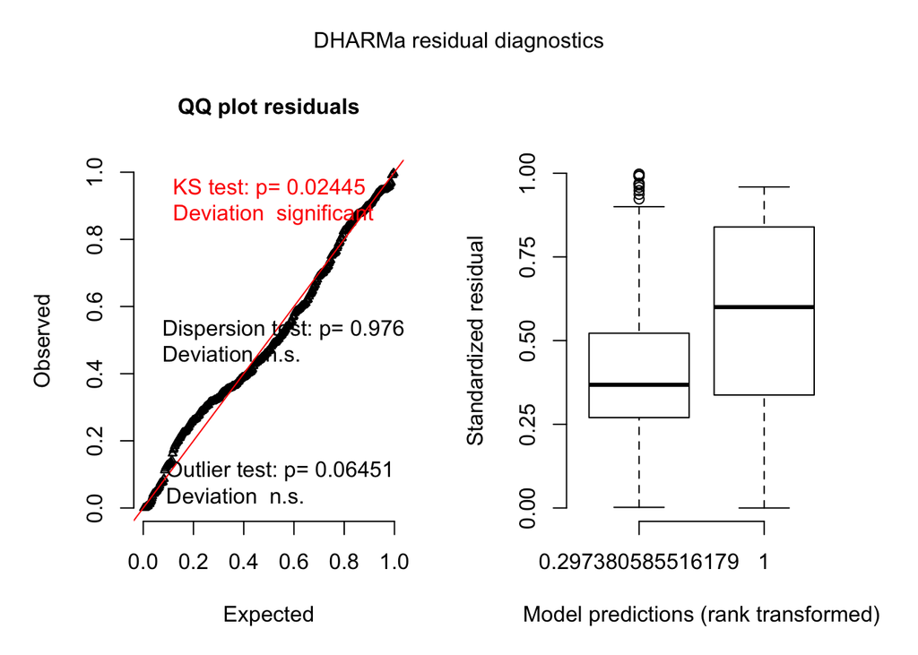

There is a significant deviation from uniformity as indicated by the significant Kolmogorov-Smirnov test. However, this model has a particularly large sample size (n = 456) so even slight deviations will be significant. Looking at the effect size of the deviation (D = 0.0694912) shows that it is minor (D < 0.1) and visual inspection does not suggest large deviations in the residuals so our model is still appropriate.

##### Results

| Factor | Estimate | Std. Error | T statistic | df | P value |
| --- | --- | --- | --- | --- | --- |
| Intercept | 42.532 | 11.918 | 3.569 | 36.95 | 0.001 |
| Ate | 91.185 | 10.953 | 8.325 | 223.75 | < .001 |

Throughout all of training, fish that ate during a session spent on average 91.2 more seconds near the rewarded object compared to fish that did not eat (Figure, 5, p < .001). Fish that spent more trials eating may therefore have received more reinforcement for the object-food association. This result is what led me to investigate whether there was a difference in food reinforcement between the two treatments in Model 4.

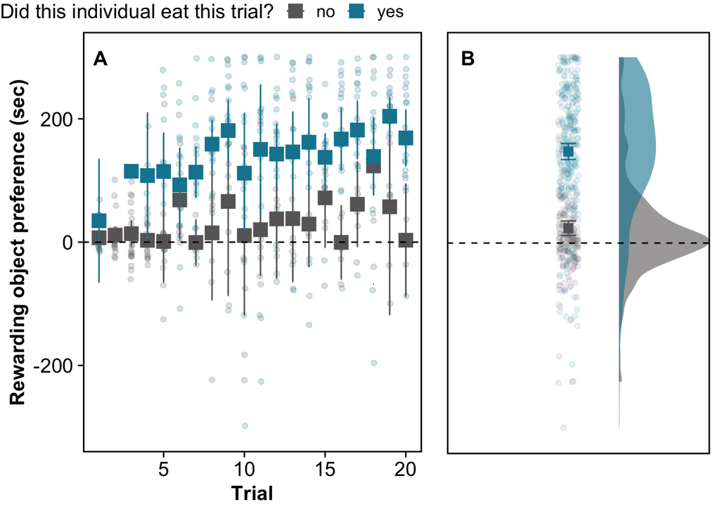

Figure 5: Preference for the rewarding object during training based on whether an individual ate during a trial or not. Dashed line represents the no preference value. In panel A, Data are means ± 95% CI. In panel B, the data consist of all the feeding choices of all individuals across all training trials. Data are means ± 95% CI with probability density functions to the right of the raw data.

## Tools used and References

A complete list of the tools used is produced below

| Package | Version | Reference |
| --- | --- | --- |
| broom | 0.5.5 | David Robinson and Alex Hayes (2020). broom: Convert Statistical Analysis Objects into Tidy Tibbles. R package version 0.5.5. https://CRAN.R-project.org/package=broom |
| broom.mixed | 0.2.6 | Ben Bolker and David Robinson (2020). broom.mixed: Tidying Methods for Mixed Models. R package version 0.2.6. https://CRAN.R-project.org/package=broom.mixed |
| carData | 3.0.3 | John Fox, Sanford Weisberg and Brad Price (2019). carData: Companion to Applied Regression Data Sets. R package version 3.0-3. https://CRAN.R-project.org/package=carData |
| cowplot | 1.0.0 | Claus O. Wilke (2019). cowplot: Streamlined Plot Theme and Plot Annotations for ‘ggplot2’. R package version 1.0.0. https://CRAN.R-project.org/package=cowplot |
| DHARMa | 0.3.3.0 | Florian Hartig (2020). DHARMa: Residual Diagnostics for Hierarchical (Multi-Level / Mixed) Regression Models. R package version 0.3.3.0. http://florianhartig.github.io/DHARMa/ |
| dplyr | 1.0.3 | Hadley Wickham, Romain François, Lionel Henry and Kirill Müller (2021). dplyr: A Grammar of Data Manipulation. R package version 1.0.3. https://CRAN.R-project.org/package=dplyr |
| effects | 4.1.4 | John Fox and Sanford Weisberg (2019). An R Companion to Applied Regression, 3rd Edition. Thousand Oaks, CA http://tinyurl.com/carbook |
| emmeans | 1.5.1 | Russell Lenth (2020). emmeans: Estimated Marginal Means, aka Least-Squares Means. R package version 1.5.1. https://CRAN.R-project.org/package=emmeans |
| ggplot2 | 3.3.3 | H. Wickham. ggplot2: Elegant Graphics for Data Analysis. Springer-Verlag New York, 2016. |
| ggpubr | 0.2.5 | Alboukadel Kassambara (2020). ggpubr: ‘ggplot2’ Based Publication Ready Plots. R package version 0.2.5. https://CRAN.R-project.org/package=ggpubr |
| glmmTMB | 1.0.0 | Mollie E. Brooks, Kasper Kristensen, Koen J. van Benthem, Arni Magnusson, Casper W. Berg, Anders Nielsen, Hans J. Skaug, Martin Maechler and Benjamin M. Bolker (2017). glmmTMB Balances Speed and Flexi… |
| knitr | 1.30 | Yihui Xie (2020). knitr: A General-Purpose Package for Dynamic Report Generation in R. R package version 1.30. |
| lme4 | 1.1.21 | Douglas Bates, Martin Maechler, Ben Bolker, Steve Walker (2015). Fitting Linear Mixed-Effects Models Using lme4. Journal of Statistical Software, 67(1), 1-48. doi:10.18637/jss.v067.i01. |
| lmerTest | 3.1.1 | Kuznetsova A, Brockhoff PB, Christensen RHB (2017). “lmerTest Package:Tests in Linear Mixed Effects Models.” *Journal of StatisticalSoftware*, *82*(13), 1-26. doi: 10.18637/jss.v082.i13 (URL:https://d… |
| magrittr | 2.0.1 | Stefan Milton Bache and Hadley Wickham (2020). magrittr: A Forward-Pipe Operator for R. R package version 2.0.1. https://CRAN.R-project.org/package=magrittr |
| MASS | 7.3.51.4 | Venables, W. N. & Ripley, B. D. (2002) Modern Applied Statistics with S. Fourth Edition. Springer, New York. ISBN 0-387-95457-0 |
| Matrix | 1.2.18 | Douglas Bates and Martin Maechler (2019). Matrix: Sparse and Dense Matrix Classes and Methods. R package version 1.2-18. https://CRAN.R-project.org/package=Matrix |
| R | 3.6.2 | R Core Team (2019). R: A language and environment for statistical computing. R Foundation for Statistical Computing, Vienna, Austria. URL https://www.R-project.org/. |
| report | 0.2.0 | Makowski, D., Ben-Shachar, M.S., Patil, I. & Lüdecke, D. (2020). Automated reporting as a practical tool to improve reproducibility and methodological best practices adoption. CRAN. Available from htt… |
| tidyext | 0.3.6 | Michael Clark (2021). tidyext: Tidy Extensions for Data Processing. https://m-clark.github.io/tidyext, https://github.com/m-clark/tidyext. |
| tidyr | 1.0.2 | Hadley Wickham and Lionel Henry (2020). tidyr: Tidy Messy Data. R package version 1.0.2. https://CRAN.R-project.org/package=tidyr |